# Course 6 - Statistical Inference - Week 3 - Notes

Greg Foletta

2019-12-30

# T Confidence Intervals

We previously discussed confidence intervals of the form $Estimate \pm ZQ \times StdErr_{Est}$.

Where $ZQ$ is a standard distribution quantile.

We’ll now look at methods for small samples, which will use $Estimate \pm TQ \times StdErr_{Est}$, where $TQ$ is a T-distribution quantile.

## Gosset’s t distribution

Invented by William Gosset under the pseudonym ‘Student’. Hence “Student’s t-distribution”.

Thicker tails, and indexed by degrees of freedom, rather than mean and variance.

It assumes the underlying data are IID Gaussian with the result that

$$\frac{
\bar{X} - \mu
}{
S / \sqrt{n}
}$$

follows Gosset’s t distribution with $n-1$ degrees of freedom.

When we replace $\sigma$ with $S$, the sample standard deviation, it turns into a t-distribution. When $n$ increases, the distinction becomes irrelevant, but with small $n$ the distinction can be quite wide. If you use the standard normal with small sample sizes you get confidence intervals that are too narrow.

Interval is $\bar{X} \pm t_{n-1} S / \sqrt{n}$, where $t_{n-1}$ is the relevant quantile.

We take a look at the t-distribution versus a standard normal with 3 degrees of freedom:

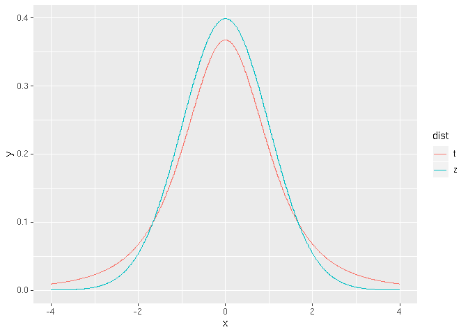

```r
tibble(
    x = seq(-4, 4, 0.01),
    z = dnorm(x),
    t = dt(x, 3)
) %>%
    gather('dist', 'y', c('z', 't')) %>%
    ggplot() +
    geom_line(aes(x, y, colour = dist))
```

We can see the tails are much fatter.

## Notes

- Technically assumes the data are IID normal, though it is robust in this assumption.
- Works well whenever the disibutrion is roughly symmetric and mound shaped.
- Paired observations are often analysed using the t interval by taking differences.
  - For example measuring something once, then measuring it again a day later.
- For large degrees of freedom, the t quantiles become the same as standard normal quantiles.
  - Suggest always use the t-interval.
- For skewed distributions, the spirit of the t interval assumptions are violated.
  - Consider taking logs or using a different summary like the median.
- For discrete data, other intevals such as the Poisson are available.

## Independent Group t Confidence Intervals

- Suppose we want to compare the mean blood pressure between two groups in a randomised trial: those who received the treatment and those who received a placebo.
- We cannot use the paired t test because groups are independent and may have different sample sizes.

The confidence interval is:

$$\bar{Y} - \bar{X} \pm
t_{n_x + n_y-2,1-\alpha/2}
S_p
\bigg(\frac{1}{n_x} + \frac{1}{n_y}\bigg) ^ {1/2}$$

- The mean of group $Y$ minus the mean of group $X$
- Times the relevant t quantile
  - The degrees of freedom are $n_x + n_y - 2$, where $n_{foo}$ is the number of observations in a group.
- The entire $S_p$ section is the standard error of the difference.
  - Notice that as the number observations grows, $n$ gets large and so this entire section gets smaller.

The $S_p^2$ is the pooled variance:

$$S^2_p = \frac{
(n_x-1)S^2_x + (n_y-1)S^2_y
}{
n_x + n_y -2
}$$
If we’re willing to assume that the variance is the same in each group - which is reasonable given they’re randomised. However the sample sizes are differnet, so we need to weight the variances.

Remember this assumes the same variance.

# Two Group Unequal Variance Test

If the $x$ oservations and the $y$ observations are IID normal, potentially with different means and different variances, the relevant normalised statistic does not follow a t-distribution.

When there are unequal variances between the groups, a **Welch’s t-test** should be used.

The confidence interval is:

$$\bar{Y} - \bar{X} \pm t_{df} \times
\bigg(
\frac{ s^2_x }{ n_x } +
\frac{ s^2_y }{ n_y }
\bigg)^{1/2}$$
It can be approximated by a rather elaborate formula for the degrees of freedom:

$$df = \frac{
(S^2_x/n_x + S^2_y/n_y)^2
}{
\bigg(\frac{S^2_x}{n_x}\bigg)^2 / (n_x - 1) +
\bigg(\frac{S^2_y}{n_y}\bigg)^2 / (n_y - 1)
}$$

Shifting around, the t-statistic is:

$$t = \frac{
\bar{Y} - \bar{X}
}{
\sqrt{ \frac{ s_x^2 }{ n_x } + \frac{ s_y^2 }{ n_y } }
}$$

When you’re in doubt, use the unequal variance.

## Other Kinds of Data

For binomial data there’s lots of ways to compare two groups:

- Relative risk, risk difference, odds ratio.
- Chi-squared tests, normal approximations, exact tests.

For count data, there’s also chi-squared tests and exact tests.

# Hypothesis Testing

Starts with the null hypothesis represents the status quo, and is usually labeled $H_0$. The null hypothesis is assumed to be true and statistical evidence is required to reject it.

Four scenarios:

- Accept the null
- Type I error (false positive)
- Reject the null
- Type II error (false negative)

Consider a court of law, the null hypothesis is that the defendant is innocent. We require a standard on the available evidence to reject the null hypothesis and convict.

If we set a low standard, we increase the amount of people convicted (type I errors). However we would increase the percentage of guilty people convicted (correctly rejecting the null).

If we set a high standard, we increase the percentage of people let free (correctly accepting the null) while we would also increase the percentage of guilty people let free.

## Rejection

We reject the null hypothesis if $\bar{X}$ was larger than some constant, $C$. $C$ is chosen so that the probability of a type I error, $\alpha$, is 0.05. $\alpha = \text{Type I error rate}$, which is the probability of rejecting the NH when in fact the hypothesis is correct.

The standard of the error is $\sigma^2/\sqrt{n}$. Under $H_0 \bar{X} \sim N(\mu, \sigma)$. We want to chose C so that $P(\bar{X} \gt C; H_0)$ is 5%.

The 95th percentile of a standard deviation is 1.645, so $C = \mu + 1 \times 1.645$.

In general we don’t convert $C$ back to the original scale, we can just reject because of the **Z-score**, which is how many standard errors the sample mean is above the hypothesised mean.

Formally, whenever:

$$\frac{ \sqrt{n}(\bar{X} - \mu_0) }{ s } \gt Z_{1-\alpha}$$

# T Tests

When $n$ is small (e.g. 16) the test statistic, how many estimated standard errors from the hypothesised mean the sample mena is, follows a T-distribution with $n-1$ (e.g. 15) degrees of freedom.

We then calculate the 95th percentile of the T-distribution rather than the normal (`qw(.95, x)`).

The two sided tests rejects the null if it’s too big *or* too small. Often used even if it doesn’t make sense in the scientific setting.

In order to get the 5% probability of rejecting the null, we’ve got 2.5% on each tail. We thus use `qt(0.975, 15)`.

## Single Group T-Test

Let’s consider we have a sample from a single group. In our case it’s 10 random normal observations. Let our null hypothesis be that the true mean is 0. We then run a t.test on it:

```r
set.seed(1)

t.test(rnorm(10))
```

```
##
##  One Sample t-test
##
## data:  rnorm(10)
## t = 0.53557, df = 9, p-value = 0.6052
## alternative hypothesis: true mean is not equal to 0
## 95 percent confidence interval:
##  -0.4261948  0.6906003
## sample estimates:
## mean of x
## 0.1322028
```

```r
t.test(rnorm(10, mean = 2))
```

```
##
##  One Sample t-test
##
## data:  rnorm(10, mean = 2)
## t = 6.6493, df = 9, p-value = 9.382e-05
## alternative hypothesis: true mean is not equal to 0
## 95 percent confidence interval:
##  1.48376 3.01393
## sample estimates:
## mean of x
##  2.248845
```

The t-statistic is the ratio of the departure of the estimated value from its hypothesised value to the standard error.

$$t_{\hat{\beta}} = \frac{ \hat{\beta} - \beta_0 }{ SE(\hat{\beta} ) }$$
where $\beta_0 = 0$

In the first test, the t-statistic is small, so we **cannot** reject the null hypothesis.

In the second the t-statistic is larger, so we can be confident in rejecting the null hypothesis.

## Paired T-Test

The paired t-test is the same as a single group, except we’re taking the differences between two observations.

Note below that the outcomes are the same:

```r
sample_a <- rnorm(10)
sample_b <- rnorm(10, mean = 10)

t.test(sample_a, sample_b, paired = T)
```

```
##
##  Paired t-test
##
## data:  sample_a and sample_b
## t = -27.034, df = 9, p-value = 6.279e-10
## alternative hypothesis: true difference in means is not equal to 0
## 95 percent confidence interval:
##  -11.112461  -9.396346
## sample estimates:
## mean of the differences
##                -10.2544
```

```r
t.test(sample_a - sample_b)
```

```
##
##  One Sample t-test
##
## data:  sample_a - sample_b
## t = -27.034, df = 9, p-value = 6.279e-10
## alternative hypothesis: true mean is not equal to 0
## 95 percent confidence interval:
##  -11.112461  -9.396346
## sample estimates:
## mean of x
##  -10.2544
```

## Two Group Intervals

We know how to do two group T tests: we have covered independent group T intervals. The rejection rules are the same, except we’re testing $H_0 : \mu_1 = \mu_2$

We can do tests where the variance is the same or different in both groups. By default `t.test()` does an unequal variance Welch test.

```r
set.seed(1)
group_a <- rnorm(10)
group_b <- rnorm(10, mean = 3)
group_c <- rnorm(10, mean = 3, sd = 4)

t.test(group_a, group_b, var.equal = T)
```

```
##
##  Two Sample t-test
##
## data:  group_a and group_b
## t = -7.4434, df = 18, p-value = 6.737e-07
## alternative hypothesis: true difference in means is not equal to 0
## 95 percent confidence interval:
##  -3.996318 -2.236966
## sample estimates:
## mean of x mean of y
## 0.1322028 3.2488450
```

```r
t.test(group_a, group_c)
```

```
##
##  Welch Two Sample t-test
##
## data:  group_a and group_c
## t = -1.8911, df = 9.7493, p-value = 0.08865
## alternative hypothesis: true difference in means is not equal to 0
## 95 percent confidence interval:
##  -5.0915810  0.4253725
## sample estimates:
## mean of x mean of y
## 0.1322028 2.4653070
```

Notice the fractional degrees of freedom in the second test, and that the t-statistic is low due to the variability in the second group which adds ‘noise’.1

# P-Values

P-values are a conveinient way to communicate the results of a hypothesis test. Formally the p-value is the probability of getting data as or more extreme than the observed data in favor of the alternative. The calculation is done assuming the null is true.

**Approach**:

- Define the hypothetical distribution of a data summary (statistic) when “nothing is going on” - the *null hypothesis*.
- Calculate the summary/statistic with the data we have - *test statistic*.
- Compare what we calculated to our hyptothetical distribution and see if the value is “extreme” - *p-value*.

If the P-value is small, then either $H_0$ is true and we have observed a rare event, or $H_0$ is false.

## Example

We get a t-statistic of 2.5 for 15 degrees of freedom testing $H_0 : \mu = \mu_0$ versus $H_a : \mu \gt \mu_0$

What’s the probability of getting a T-statistic as large as 2.5?

```r
pt(q = 2.5, df = 15, lower.tail = F)
```

```
## [1] 0.0122529
```

We see the probabilit is 1.2%.

For a two sided hypothesis test where the critical area is on both tails of the distribution, double the smaller of the two one-sided hypothesis test values to take into account the tails. Most times software that reports the p-value is performing a two-tailed test.

## Poisson Example

*Suppose that a hospital has an infection rate of 10 infections per 100 person/days at a risk (rate) of 0.1 during the last monitoring period.*

*Assume that an infection rate of 0.05 is an important benchmark. Given the model, could the observed rate being larger than 0.05 be attributed to chance?*

- Under $H_0 : \lambda = 0.05$ so that $\lambda_0 \times 100 = 5$.
- Consider $H_a : \lambda \gt 0.05$

```r
# The 9 is (10 - 1) so that we're getting the upper tail or "10 or more"
ppois(9, 5, lower.tail = F)
```

```
## [1] 0.03182806
```